# Máster en Data Science - Machine Learning

# Exploratory Data Analysis (EDA)

Autores: Frida Ibarra Y Gema Romero

#### **Notebook 2 (Data_Treatment)**

Centrado en el tratamiento de los datos. El procesamiento de datos es una etapa clave para garantizar que los algoritmos de modelado funcionen de manera eficiente y precisa. A continuación, se detalla el enfoque estructurado para preparar y transformar los datos:

Va a seguir la siguiente estructura:

1. Separación Train y Test: La división de los datos en conjuntos de entrenamiento y prueba es esencial para evaluar la capacidad del modelo para generalizar a nuevos datos.
2. Tratamiento de outliers: Los valores atípicos pueden sesgar los resultados del modelo o influir negativamente en el rendimiento.
3. Análisis de relaciones entre variables

   3.1. Matriz de correlación. Calcula las correlaciones entre variables numéricas usando el coeficiente de Pearson. Ayuda a identificar multicolinealidad, es decir, relaciones muy fuertes entre variables independientes, lo que puede afectar el rendimiento del modelo.

   3.2. Matriz de Cramer. Para evaluar relaciones entre variables categóricas, se utiliza la V de Cramer, un indicador de asociación que varía entre 0 (sin relación) y 1 (relación perfecta). Esto permite identificar qué variables categóricas tienen una relación significativa entre sí o con la variable objetivo, ayudando a decidir si es necesario combinarlas, transformarlas o eliminarlas.
4. WOE y Valor de la Información (Information Value). Ayuda a evaluar la calidad predictiva de las variables

### IMPORTACIÓN DE LIBRERIAS

```python
# Librerías
import os
import pandas as pd
import numpy as np
import openpyxl
import missingno as msno
from colorama import Fore, Style
import seaborn as sns
import matplotlib.pyplot as plt
import sys
from sklearn.model_selection import train_test_split
import scipy.stats
```

### FUNCIONES AUXILIARES

```python
#Funciones

sys.path.append('../src')  # Asegúrate de que ../src es la carpeta donde está Funciones_Ayuda.py
import functions_src as fa  # Ahora debería importarse correctamente
sys.path.remove('../src')

#Semilla
seed = 25
```

### IMPORTACIÓN DEL ANÁLISIS PREVIO

```python
# Obtener la ruta del directorio de trabajo actual
ruta_actual = os.getcwd()
ruta_actual
```

```
'c:\\Users\\gemuc\\OneDrive\\Escritorio\\master5\\aprendizaje\\practica1_EDA\\notebooks'
```

```python
#lectura del dataset
data = '../data/Processing_data/application_data(1).csv'
df_loans = pd.read_csv(data)
df_loans
```

|  | Unnamed: 0 | SK_ID_CURR | TARGET | NAME_CONTRACT_TYPE | CODE_GENDER | FLAG_OWN_CAR | FLAG_OWN_REALTY | CNT_CHILDREN | AMT_INCOME_TOTAL | AMT_CREDIT | ... | FLAG_DOCUMENT_18 | FLAG_DOCUMENT_19 | FLAG_DOCUMENT_20 | FLAG_DOCUMENT_21 | AMT_REQ_CREDIT_BUREAU_HOUR | AMT_REQ_CREDIT_BUREAU_DAY | AMT_REQ_CREDIT_BUREAU_WEEK | AMT_REQ_CREDIT_BUREAU_MON | AMT_REQ_CREDIT_BUREAU_QRT | AMT_REQ_CREDIT_BUREAU_YEAR |
| --- | --- | --- | --- | --- | --- | --- | --- | --- | --- | --- | --- | --- | --- | --- | --- | --- | --- | --- | --- | --- | --- |
| 0 | 0 | 100002 | 1 | Cash loans | M | N | Y | 0 | 202500.0 | 406597.5 | ... | 0 | 0 | 0 | 0 | 0.0 | 0.0 | 0.0 | 0.0 | 0.0 | 1.0 |
| 1 | 1 | 100003 | 0 | Cash loans | F | N | N | 0 | 270000.0 | 1293502.5 | ... | 0 | 0 | 0 | 0 | 0.0 | 0.0 | 0.0 | 0.0 | 0.0 | 0.0 |
| 2 | 2 | 100004 | 0 | Revolving loans | M | Y | Y | 0 | 67500.0 | 135000.0 | ... | 0 | 0 | 0 | 0 | 0.0 | 0.0 | 0.0 | 0.0 | 0.0 | 0.0 |
| 3 | 3 | 100006 | 0 | Cash loans | F | N | Y | 0 | 135000.0 | 312682.5 | ... | 0 | 0 | 0 | 0 | NaN | NaN | NaN | NaN | NaN | NaN |
| 4 | 4 | 100007 | 0 | Cash loans | M | N | Y | 0 | 121500.0 | 513000.0 | ... | 0 | 0 | 0 | 0 | 0.0 | 0.0 | 0.0 | 0.0 | 0.0 | 0.0 |
| ... | ... | ... | ... | ... | ... | ... | ... | ... | ... | ... | ... | ... | ... | ... | ... | ... | ... | ... | ... | ... | ... |
| 307506 | 307506 | 456251 | 0 | Cash loans | M | N | N | 0 | 157500.0 | 254700.0 | ... | 0 | 0 | 0 | 0 | NaN | NaN | NaN | NaN | NaN | NaN |
| 307507 | 307507 | 456252 | 0 | Cash loans | F | N | Y | 0 | 72000.0 | 269550.0 | ... | 0 | 0 | 0 | 0 | NaN | NaN | NaN | NaN | NaN | NaN |
| 307508 | 307508 | 456253 | 0 | Cash loans | F | N | Y | 0 | 153000.0 | 677664.0 | ... | 0 | 0 | 0 | 0 | 1.0 | 0.0 | 0.0 | 1.0 | 0.0 | 1.0 |
| 307509 | 307509 | 456254 | 1 | Cash loans | F | N | Y | 0 | 171000.0 | 370107.0 | ... | 0 | 0 | 0 | 0 | 0.0 | 0.0 | 0.0 | 0.0 | 0.0 | 0.0 |
| 307510 | 307510 | 456255 | 0 | Cash loans | F | N | N | 0 | 157500.0 | 675000.0 | ... | 0 | 0 | 0 | 0 | 0.0 | 0.0 | 0.0 | 2.0 | 0.0 | 1.0 |

307511 rows × 123 columns

```python
library = '../data/columns_description.xlsx'
df_loans_dictionary = pd.read_excel(library)
df_loans_dictionary.head()
```

|  | Unnamed: 0 | Table | Row | Description | Special |
| --- | --- | --- | --- | --- | --- |
| 0 | 1 | application_data | SK_ID_CURR | ID of loan in our sample | NaN |
| 1 | 2 | application_data | TARGET | Target variable (1 - client with payment diffi... | NaN |
| 2 | 5 | application_data | NAME_CONTRACT_TYPE | Identification if loan is cash or revolving | NaN |
| 3 | 6 | application_data | CODE_GENDER | Gender of the client | NaN |
| 4 | 7 | application_data | FLAG_OWN_CAR | Flag if the client owns a car | NaN |

```python
#Se elimina la primera columna porque se repite el índice.
df_loans.drop(columns=['Unnamed: 0'], inplace=True)
```

### SEPARACIÓN TRAIN Y TEST

Para realizar la separación de Train y Test hay que cerciorarse de que la variable Target no sufre cambios en sus proporciones. Las proporciones, previamente calculadas en el Notebook 1, son las siguientes:

```python
# Crear el DataFrame de la variable TARGET con el conteo de valores
target_df_count = df_loans['TARGET'].value_counts().reset_index()

#Crea el dataframe de la variable TARGET y su distribución en porcentaje
target_df_percent = df_loans['TARGET']\
    .value_counts(normalize=True)\
    .mul(100).rename('percent').reset_index()\
    .round(2)

#Mergear los dataframes
target_df_merge = pd.merge(target_df_count, target_df_percent, on='TARGET', how='inner')
target_df_merge
```

|  | TARGET | count | percent |
| --- | --- | --- | --- |
| 0 | 0 | 282686 | 91.93 |
| 1 | 1 | 24825 | 8.07 |

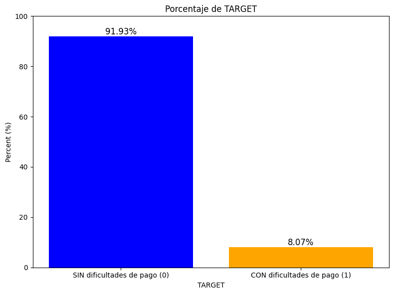

```python
fig, ax = plt.subplots(figsize = (8,6)) #cuadrícula

# Crear gráfico de barras
bar_plot= plt.bar(target_df_merge['TARGET'], target_df_merge['percent'], color=['blue', 'orange'])

#ajustar el limite superior del eje y
plt.ylim(0, 100)

# Agregar etiquetas con el porcentaje de cada valor encima de las barras
for bar in bar_plot:
    yvalue = bar.get_height()  # Obtener la altura de cada barra
    plt.text(bar.get_x() + bar.get_width() / 2, yvalue + 0.02, f'{yvalue:.2f}%',
             ha='center', va='bottom', fontsize=12)


# Agregar etiquetas y título al gráfico
plt.xlabel('TARGET')
ax.set_xticks([0,1], labels=['SIN dificultades de pago (0)', 'CON dificultades de pago (1)'])
plt.ylabel('Percent (%)')
plt.title('Porcentaje de TARGET')
plt.xticks(target_df_merge['TARGET'])  # Asegura que las etiquetas del eje X sean correctas
plt.tight_layout()
plt.show()
```

Inicialmente, la distribución 80/20 parece adecuada para las necesidades actuales, aunque no se descarta ajustar esta proporción en el futuro, por ejemplo, con un esquema 70/15/15 que incluya un conjunto dedicado a la validación cruzada.

```python
X_df_loans_train, X_df_loans_test, y_df_loans_train, y_df_loans_test = train_test_split(
    df_loans.drop('TARGET', axis=1), #Se elimina la variable target para usar el resto como variables predictorias (X)
    df_loans['TARGET'], #variable target (y)
    stratify=df_loans['TARGET'], #asegura la estratificación de la variable target
    test_size=0.2, #tamaño del conjunto de prueba.
    random_state=seed
)

df_loans_train = pd.concat([X_df_loans_train, y_df_loans_train],axis=1)
df_loans_test = pd.concat([X_df_loans_test, y_df_loans_test],axis=1)
```

Comparamos las proporciones para asegurarnos de que la estratificación se ha realizado bien:

```python
# Proporción en el conjunto original
print("Distribución original:")
print(df_loans['TARGET'].value_counts(normalize=True))

# Proporción en el conjunto de entrenamiento
print("\nDistribución en el conjunto de entrenamiento:")
print(y_df_loans_train.value_counts(normalize=True))

# Proporción en el conjunto de prueba
print("\nDistribución en el conjunto de prueba:")
print(y_df_loans_test.value_counts(normalize=True))
```

```
Distribución original:
TARGET
0    0.919271
1    0.080729
Name: proportion, dtype: float64

Distribución en el conjunto de entrenamiento:
TARGET
0    0.919271
1    0.080729
Name: proportion, dtype: float64

Distribución en el conjunto de prueba:
TARGET
0    0.919272
1    0.080728
Name: proportion, dtype: float64
```

Se puede afirmar que la estratificación ha sido realizada de manera correcta ya que se preservan las proporciones de la variable objetivo para dataset de train como de test

Se debe tener presente que la variable objetivo está muy desbalanceada. En este caso implica que hay muy pocos clientes que tengan dificultades en el pago del préstamo (8,07%) frente a una grán proporción de los clientes que no presentan dificultades a la hora de pagar (91.93%). Por ello, es posible que, previo a la ejecución del modelado, se requiera un procesamiento de oversampling para compensar de cierta manera ese desbalance.

### TRATAMIENTO DE OUTLIERS

```python
#primero se seleccionan las numéricas sin las buleanas
columnas_numericas_sin_booleanas = [col for col in df_loans_train.select_dtypes(include=[np.number]).columns if df_loans_train[col].dtype != 'bool']

# Ver los nombres de las columnas
print(columnas_numericas_sin_booleanas)
```

```
['SK_ID_CURR', 'CNT_CHILDREN', 'AMT_INCOME_TOTAL', 'AMT_CREDIT', 'AMT_ANNUITY', 'AMT_GOODS_PRICE', 'REGION_POPULATION_RELATIVE', 'DAYS_BIRTH', 'DAYS_EMPLOYED', 'DAYS_REGISTRATION', 'DAYS_ID_PUBLISH', 'OWN_CAR_AGE', 'FLAG_MOBIL', 'FLAG_EMP_PHONE', 'FLAG_WORK_PHONE', 'FLAG_CONT_MOBILE', 'FLAG_PHONE', …
```

```python
pd.set_option('display.max_rows', None)
```

```python
fa.get_deviation_of_mean_perc(df_loans_train, columnas_numericas_sin_booleanas, target='TARGET', multiplier=3)
```

|  | variable | sum_outlier_values | porcentaje_sum_null_values | 0 | 1 |
| --- | --- | --- | --- | --- | --- |
| 68 | FLAG_DOCUMENT_6 | 21611 | 0.087847 | 0.945074 | 0.054926 |
| 70 | FLAG_DOCUMENT_8 | 20016 | 0.081363 | 0.925510 | 0.074490 |
| 90 | TARGET | 19860 | 0.080729 | NaN | 1.000000 |
| 16 | REG_CITY_NOT_LIVE_CITY | 19214 | 0.078103 | 0.876757 | 0.123243 |
| 10 | FLAG_EMAIL | 13974 | 0.056803 | 0.921640 | 0.078360 |
| 14 | REG_REGION_NOT_WORK_REGION | 12515 | 0.050872 | 0.912265 | 0.087735 |
| 15 | LIVE_REGION_NOT_WORK_REGION | 10064 | 0.040909 | 0.916832 | 0.083168 |
| 86 | AMT_REQ_CREDIT_BUREAU_WEEK | 6839 | 0.027800 | 0.921334 | 0.078666 |
| 5 | REGION_POPULATION_RELATIVE | 6637 | 0.026979 | 0.959922 | 0.040078 |
| 61 | DEF_30_CNT_SOCIAL_CIRCLE | 5493 | 0.022329 | 0.881668 | 0.118332 |
| 60 | OBS_30_CNT_SOCIAL_CIRCLE | 4922 | 0.020007 | 0.909793 | 0.090207 |
| 62 | OBS_60_CNT_SOCIAL_CIRCLE | 4783 | 0.019442 | 0.909262 | 0.090738 |
| 67 | FLAG_DOCUMENT_5 | 3754 | 0.015260 | 0.920352 | 0.079648 |
| 13 | REG_REGION_NOT_LIVE_REGION | 3711 | 0.015085 | 0.908380 | 0.091620 |
| 0 | CNT_CHILDREN | 3426 | 0.013926 | 0.897548 | 0.102452 |
| 4 | AMT_GOODS_PRICE | 3342 | 0.013585 | 0.960203 | 0.039797 |
| 11 | CNT_FAM_MEMBERS | 3212 | 0.013056 | 0.899440 | 0.100560 |
| 63 | DEF_60_CNT_SOCIAL_CIRCLE | 3152 | 0.012813 | 0.875952 | 0.124048 |
| 7 | OWN_CAR_AGE | 2677 | 0.010882 | 0.920433 | 0.079567 |
| 36 | ELEVATORS_MODE | 2674 | 0.010870 | 0.949514 | 0.050486 |
| 42 | LIVINGAREA_MODE | 2673 | 0.010866 | 0.947624 | 0.052376 |
| 89 | AMT_REQ_CREDIT_BUREAU_YEAR | 2660 | 0.010813 | 0.904135 | 0.095865 |
| 59 | TOTALAREA_MODE | 2622 | 0.010658 | 0.956522 | 0.043478 |
| 2 | AMT_CREDIT | 2604 | 0.010585 | 0.957373 | 0.042627 |
| 87 | AMT_REQ_CREDIT_BUREAU_MON | 2584 | 0.010504 | 0.946981 | 0.053019 |
| 56 | LIVINGAREA_MEDI | 2580 | 0.010487 | 0.951550 | 0.048450 |
| 28 | LIVINGAREA_AVG | 2557 | 0.010394 | 0.949941 | 0.050059 |
| 78 | FLAG_DOCUMENT_16 | 2443 | 0.009931 | 0.951289 | 0.048711 |
| 31 | APARTMENTS_MODE | 2407 | 0.009784 | 0.950145 | 0.049855 |
| 45 | APARTMENTS_MEDI | 2398 | 0.009748 | 0.949541 | 0.050459 |

[output cut: 61 more lines]

Dada la naturaleza del análisis actual y la distribución de los valores outliers identificados, no se considera prioritario tratarlos en esta etapa inicial. Muchas de las variables afectadas por valores extremos, como las banderas documentales o indicadores específicos, tienen un impacto relativamente pequeño en el conjunto total de datos (proporciones menores al 10%). Además, su naturaleza discreta sugiere que estos valores podrían representar información útil en lugar de ruido o errores.

No obstante, no se descarta la posibilidad de abordar los outliers en fases futuras del análisis, especialmente si afectan la estabilidad o el desempeño de modelos predictivos posteriores. El enfoque en este momento se centra en preservar la integridad de los datos y explorar cómo estas anomalías interactúan con la variable objetivo antes de tomar decisiones de tratamiento definitivo.

### ANÁLISIS DE RELACIONES ENTRE LAS VARIABLES

#### CORRELACIÓN ENTRE VARIABLES

```python
boolean_columns = df_loans.columns[df_loans.isin([0, 1]).all()]

corr = pd.concat([df_loans_train.select_dtypes('number').drop(boolean_columns, axis=1), df_loans_train['TARGET']], axis=1).corr(method='pearson')
corr
```

|  | SK_ID_CURR | CNT_CHILDREN | AMT_INCOME_TOTAL | AMT_CREDIT | AMT_ANNUITY | AMT_GOODS_PRICE | REGION_POPULATION_RELATIVE | DAYS_BIRTH | DAYS_EMPLOYED | DAYS_REGISTRATION | ... | OBS_60_CNT_SOCIAL_CIRCLE | DEF_60_CNT_SOCIAL_CIRCLE | DAYS_LAST_PHONE_CHANGE | AMT_REQ_CREDIT_BUREAU_HOUR | AMT_REQ_CREDIT_BUREAU_DAY | AMT_REQ_CREDIT_BUREAU_WEEK | AMT_REQ_CREDIT_BUREAU_MON | AMT_REQ_CREDIT_BUREAU_QRT | AMT_REQ_CREDIT_BUREAU_YEAR | TARGET |
| --- | --- | --- | --- | --- | --- | --- | --- | --- | --- | --- | --- | --- | --- | --- | --- | --- | --- | --- | --- | --- | --- |
| SK_ID_CURR | 1.000000 | -0.000139 | -0.002351 | -0.000048 | -0.000167 | -0.000205 | 0.001312 | -0.000593 | 0.000636 | 0.000025 | ... | -0.001106 | 0.000700 | 0.000843 | -0.003370 | -0.001274 | 0.001692 | 0.001071 | 0.001188 | 0.004115 | -0.000916 |
| CNT_CHILDREN | -0.000139 | 1.000000 | 0.012308 | 0.000512 | 0.020594 | -0.003698 | -0.025607 | 0.331407 | -0.240391 | 0.184297 | ... | 0.015556 | -0.003911 | -0.006609 | -0.001140 | -0.002351 | -0.003979 | -0.011536 | -0.006936 | -0.040849 | 0.018478 |
| AMT_INCOME_TOTAL | -0.002351 | 0.012308 | 1.000000 | 0.143115 | 0.176164 | 0.145715 | 0.067755 | 0.025181 | -0.058853 | 0.024492 | ... | -0.012020 | -0.012415 | -0.016126 | 0.001496 | 0.002049 | 0.002801 | 0.021941 | 0.004284 | 0.010152 | -0.002301 |
| AMT_CREDIT | -0.000048 | 0.000512 | 0.143115 | 1.000000 | 0.770517 | 0.986979 | 0.098843 | -0.055084 | -0.067310 | 0.008680 | ... | 0.001595 | -0.022918 | -0.072161 | -0.002406 | 0.004803 | -0.000617 | 0.053708 | 0.017085 | -0.049557 | -0.029726 |
| AMT_ANNUITY | -0.000167 | 0.020594 | 0.176164 | 0.770517 | 1.000000 | 0.775446 | 0.116669 | 0.009278 | -0.103889 | 0.036919 | ... | -0.010913 | -0.022999 | -0.062361 | 0.005338 | 0.003305 | 0.013589 | 0.038610 | 0.011038 | -0.011484 | -0.011376 |
| AMT_GOODS_PRICE | -0.000205 | -0.003698 | 0.145715 | 0.986979 | 0.775446 | 1.000000 | 0.102610 | -0.053125 | -0.065121 | 0.010532 | ... | 0.001606 | -0.023516 | -0.074896 | -0.001904 | 0.005333 | -0.000360 | 0.055661 | 0.017664 | -0.052292 | -0.038910 |
| REGION_POPULATION_RELATIVE | 0.001312 | -0.025607 | 0.067755 | 0.098843 | 0.116669 | 0.102610 | 1.000000 | -0.029165 | -0.004381 | -0.052857 | ... | -0.009888 | 0.002931 | -0.043841 | -0.001708 | 0.000890 | -0.002318 | 0.078761 | 0.000110 | 0.001349 | -0.036726 |
| DAYS_BIRTH | -0.000593 | 0.331407 | 0.025181 | -0.055084 | 0.009278 | -0.053125 | -0.029165 | 1.000000 | -0.616128 | 0.332535 | ... | 0.007431 | 0.001393 | 0.082923 | 0.006080 | 0.000542 | -0.003452 | 0.001748 | -0.011430 | -0.070250 | 0.079297 |
| DAYS_EMPLOYED | 0.000636 | -0.240391 | -0.058853 | -0.067310 | -0.103889 | -0.065121 | -0.004381 | -0.616128 | 1.000000 | -0.210621 | ... | 0.005968 | 0.014325 | 0.023163 | -0.004727 | 0.000620 | 0.002868 | -0.034664 | 0.014973 | 0.047889 | -0.045928 |
| DAYS_REGISTRATION | 0.000025 | 0.184297 | 0.024492 | 0.008680 | 0.036919 | 0.010532 | -0.052857 | 0.332535 | -0.210621 | 1.000000 | ... | 0.008704 | 0.002988 | 0.057217 | -0.002395 | 0.000589 | -0.001145 | -0.012256 | -0.000854 | -0.024433 | 0.043999 |
| DAYS_ID_PUBLISH | -0.000660 | -0.028510 | 0.007264 | -0.005739 | 0.011125 | -0.008593 | -0.004824 | 0.272018 | -0.272314 | 0.101704 | ... | -0.014136 | 0.004667 | 0.089453 | 0.006328 | -0.000194 | 0.000012 | -0.009401 | -0.005851 | -0.035333 | 0.052957 |
| OWN_CAR_AGE | -0.001807 | 0.008219 | -0.112655 | -0.095717 | -0.097923 | -0.104941 | -0.083092 | 0.006168 | 0.026819 | -0.026176 | ... | 0.003637 | 0.012815 | 0.004325 | 0.002278 | -0.009021 | 0.001113 | -0.022490 | -0.015872 | -0.014363 | 0.035120 |
| CNT_FAM_MEMBERS | -0.001452 | 0.879098 | 0.015649 | 0.061794 | 0.074703 | 0.059601 | -0.024330 | 0.278869 | -0.233326 | 0.173974 | ... | 0.026189 | -0.006222 | -0.027636 | -0.000091 | -0.003079 | -0.002156 | -0.009092 | -0.003069 | -0.027744 | 0.008624 |
| REGION_RATING_CLIENT | -0.000511 | 0.024394 | -0.078276 | -0.101513 | -0.128046 | -0.103420 | -0.531927 | 0.009081 | 0.032872 | 0.079661 | ... | 0.034923 | 0.017396 | 0.025590 | 0.006524 | -0.002530 | 0.001091 | -0.069221 | 0.004238 | 0.011897 | 0.059819 |
| REGION_RATING_CLIENT_W_CITY | -0.000984 | 0.023929 | -0.083863 | -0.110546 | -0.141111 | -0.111738 | -0.530392 | 0.007841 | 0.034555 | 0.073180 | ... | 0.030667 | 0.016814 | 0.025122 | 0.006159 | -0.002621 | 0.000796 | -0.067365 | 0.003815 | 0.011109 | 0.061584 |
| HOUR_APPR_PROCESS_START | -0.000903 | -0.008232 | 0.033779 | 0.052636 | 0.052684 | 0.062019 | 0.170865 | 0.091031 | -0.091150 | -0.009688 | ... | -0.008928 | -0.009932 | -0.014425 | -0.016067 | 0.002953 | -0.002508 | 0.037698 | -0.000331 | -0.033224 | -0.023984 |
| EXT_SOURCE_1 | -0.000064 | -0.139605 | 0.023885 | 0.167625 | 0.118544 | 0.174308 | 0.099982 | -0.600981 | 0.290299 | -0.181103 | ... | -0.024579 | -0.030173 | -0.132220 | -0.005357 | -0.004045 | 0.000546 | 0.028258 | -0.003007 | 0.007352 | -0.155870 |
| EXT_SOURCE_2 | 0.001424 | -0.017202 | 0.055026 | 0.130480 | 0.124925 | 0.138742 | 0.197868 | -0.092231 | -0.020393 | -0.061262 | ... | -0.020179 | -0.031715 | -0.195574 | -0.002243 | 0.002219 | 0.002664 | 0.050965 | -0.003458 | -0.020777 | -0.161367 |
| EXT_SOURCE_3 | -0.000343 | -0.042785 | -0.028542 | 0.042174 | 0.029512 | 0.046557 | -0.006635 | -0.205806 | 0.115203 | -0.109823 | ... | -0.001991 | -0.033974 | -0.076097 | -0.000984 | -0.007666 | -0.020748 | -0.007486 | -0.025164 | -0.071621 | -0.180016 |
| APARTMENTS_AVG | 0.001091 | -0.012908 | 0.030757 | 0.058801 | 0.075814 | 0.063362 | 0.204351 | 0.004792 | -0.015984 | 0.014158 | ... | -0.026073 | -0.017492 | -0.005867 | 0.002562 | 0.001940 | 0.000074 | 0.035860 | -0.002276 | -0.017344 | -0.031872 |
| BASEMENTAREA_AVG | -0.002752 | -0.006941 | 0.015407 | 0.037580 | 0.043776 | 0.042383 | 0.097277 | -0.003367 | -0.001193 | -0.022416 | ... | -0.015365 | -0.014070 | -0.006059 | -0.000855 | 0.002735 | -0.001576 | 0.022550 | -0.001504 | -0.013366 | -0.023956 |
| YEARS_BEGINEXPLUATATION_AVG | 0.001983 | 0.008528 | 0.004996 | 0.006091 | 0.013146 | 0.007236 | -0.006456 | 0.000440 | 0.009167 | 0.009376 | ... | -0.002126 | -0.005551 | 0.002157 | 0.000049 | -0.001723 | 0.002362 | -0.000443 | 0.001823 | -0.007767 | -0.010922 |
| YEARS_BUILD_AVG | 0.006306 | 0.032551 | 0.040590 | 0.033699 | 0.033305 | 0.039781 | -0.055739 | 0.027369 | -0.006854 | 0.165960 | ... | -0.001307 | -0.010709 | 0.012530 | 0.005290 | 0.002662 | -0.001529 | -0.000703 | -0.007657 | -0.027326 | -0.023712 |
| COMMONAREA_AVG | -0.004399 | -0.001866 | 0.090235 | 0.047677 | 0.056364 | 0.048825 | 0.165376 | 0.008612 | -0.011284 | 0.028995 | ... | -0.023785 | -0.013979 | -0.001634 | 0.006249 | 0.004624 | -0.008525 | 0.029377 | -0.008104 | -0.015925 | -0.016621 |
| ELEVATORS_AVG | 0.004768 | -0.006983 | 0.040151 | 0.078862 | 0.100146 | 0.081880 | 0.277804 | -0.002323 | -0.009495 | 0.001539 | ... | -0.033955 | -0.024183 | -0.008573 | 0.001398 | 0.001857 | -0.000249 | 0.043738 | -0.003877 | -0.020400 | -0.035232 |
| ENTRANCES_AVG | -0.004442 | -0.007149 | 0.005416 | 0.014331 | 0.015949 | 0.018272 | 0.037481 | -0.008058 | 0.002749 | -0.062188 | ... | -0.002187 | -0.005802 | -0.011118 | -0.004734 | 0.004086 | 0.001575 | 0.014291 | 0.000398 | -0.011227 | -0.020908 |
| FLOORSMAX_AVG | 0.005564 | -0.009561 | 0.054016 | 0.103668 | 0.129606 | 0.108926 | 0.320675 | 0.001651 | -0.015174 | 0.050553 | ... | -0.038427 | -0.028203 | -0.006149 | 0.003028 | 0.001278 | -0.000088 | 0.045196 | 0.000697 | -0.020976 | -0.045791 |
| FLOORSMIN_AVG | 0.003193 | -0.007494 | 0.139345 | 0.077532 | 0.098106 | 0.079989 | 0.290802 | 0.002244 | -0.017660 | 0.023523 | ... | -0.033253 | -0.020456 | -0.007131 | 0.001488 | 0.001154 | -0.001780 | 0.039786 | -0.003994 | -0.011635 | -0.035046 |
| LANDAREA_AVG | -0.000286 | -0.001474 | -0.001550 | 0.005784 | 0.008220 | 0.012852 | -0.047314 | 0.004220 | -0.008781 | 0.003664 | ... | -0.003749 | -0.003163 | 0.000582 | -0.000300 | 0.005394 | 0.010835 | 0.015760 | 0.006380 | -0.012911 | -0.010115 |
| LIVINGAPARTMENTS_AVG | 0.002771 | -0.009786 | 0.106446 | 0.056563 | 0.074632 | 0.059625 | 0.192703 | 0.010116 | -0.018942 | 0.023921 | ... | -0.027518 | -0.017826 | -0.000239 | 0.002284 | 0.005169 | -0.002929 | 0.035512 | -0.006468 | -0.014821 | -0.026130 |
| LIVINGAREA_AVG | 0.000659 | -0.009340 | 0.035542 | 0.070114 | 0.088309 | 0.075316 | 0.212601 | 0.000111 | -0.012300 | 0.008313 | ... | -0.027905 | -0.019059 | -0.009155 | 0.005623 | 0.008221 | -0.001684 | 0.036931 | -0.001469 | -0.021159 | -0.034596 |
| NONLIVINGAPARTMENTS_AVG | -0.002007 | 0.002344 | 0.028500 | 0.014998 | 0.021808 | 0.015915 | 0.022601 | 0.000111 | -0.004304 | 0.032594 | ... | -0.002720 | -0.002295 | 0.000802 | -0.000334 | -0.000897 | -0.002965 | 0.002648 | 0.000639 | -0.003202 | -0.005257 |
| NONLIVINGAREA_AVG | 0.005360 | 0.002111 | 0.071885 | 0.035962 | 0.048516 | 0.040190 | 0.071874 | 0.005092 | -0.011561 | 0.047483 | ... | -0.014346 | -0.013222 | -0.003156 | 0.004354 | -0.000257 | -0.005974 | 0.013437 | -0.001058 | -0.009668 | -0.013443 |
| APARTMENTS_MODE | 0.001219 | -0.011745 | 0.026699 | 0.051939 | 0.066321 | 0.056536 | 0.173918 | 0.005026 | -0.014295 | 0.013660 | ... | -0.021782 | -0.016887 | -0.005706 | 0.002474 | 0.001451 | -0.000028 | 0.033279 | -0.001767 | -0.015684 | -0.029805 |
| BASEMENTAREA_MODE | -0.001949 | -0.007124 | 0.011388 | 0.029325 | 0.033717 | 0.033979 | 0.064647 | -0.003036 | -0.000523 | -0.021878 | ... | -0.011718 | -0.012690 | -0.005221 | -0.000448 | 0.002577 | -0.002120 | 0.020850 | -0.001642 | -0.012072 | -0.021377 |
| YEARS_BEGINEXPLUATATION_MODE | 0.002359 | 0.007751 | 0.004735 | 0.004915 | 0.012377 | 0.006014 | -0.006774 | 0.000034 | 0.009294 | 0.007713 | ... | -0.001533 | -0.004276 | 0.002019 | -0.000198 | -0.002244 | 0.001461 | -0.000468 | 0.002064 | -0.008017 | -0.010379 |
| YEARS_BUILD_MODE | 0.005695 | 0.032148 | 0.035471 | 0.031213 | 0.030111 | 0.037205 | -0.062920 | 0.026697 | -0.006091 | 0.164250 | ... | -0.000055 | -0.010197 | 0.012979 | 0.004997 | 0.001610 | -0.001845 | -0.001006 | -0.007370 | -0.026746 | -0.023465 |
| COMMONAREA_MODE | -0.004297 | -0.001858 | 0.075550 | 0.040072 | 0.047271 | 0.040944 | 0.131748 | 0.009840 | -0.012098 | 0.029844 | ... | -0.019811 | -0.012656 | -0.000578 | 0.005371 | 0.004809 | -0.007532 | 0.026791 | -0.007052 | -0.015239 | -0.014634 |
| ELEVATORS_MODE | 0.004852 | -0.006049 | 0.036475 | 0.072960 | 0.091883 | 0.076165 | 0.249373 | -0.001916 | -0.008363 | 0.003012 | ... | -0.029992 | -0.023148 | -0.008202 | 0.000953 | 0.001392 | -0.000424 | 0.041475 | -0.003353 | -0.019632 | -0.033578 |
| ENTRANCES_MODE | -0.004250 | -0.005133 | 0.002474 | 0.009282 | 0.009133 | 0.013357 | 0.016986 | -0.006988 | 0.003732 | -0.059166 | ... | 0.000660 | -0.005860 | -0.010667 | -0.004463 | 0.002995 | 0.001813 | 0.012388 | 0.000713 | -0.009100 | -0.019324 |
| FLOORSMAX_MODE | 0.005088 | -0.009360 | 0.051886 | 0.101037 | 0.125833 | 0.106211 | 0.302939 | 0.001208 | -0.014222 | 0.050764 | ... | -0.036424 | -0.027529 | -0.005930 | 0.003490 | 0.000814 | 0.000422 | 0.042456 | 0.001289 | -0.020792 | -0.045221 |
| FLOORSMIN_MODE | 0.001902 | -0.006345 | 0.131171 | 0.074105 | 0.092506 | 0.076266 | 0.272504 | 0.001455 | -0.017184 | 0.022285 | ... | -0.031447 | -0.019548 | -0.006723 | 0.001325 | 0.000660 | -0.001182 | 0.035868 | -0.003577 | -0.010853 | -0.033928 |
| LANDAREA_MODE | 0.000331 | -0.001092 | -0.003243 | 0.002656 | 0.004096 | 0.009534 | -0.056979 | 0.004786 | -0.007891 | 0.004043 | ... | -0.001664 | -0.003561 | 0.000235 | -0.000037 | 0.004996 | 0.008425 | 0.014120 | 0.007301 | -0.011478 | -0.009272 |
| LIVINGAPARTMENTS_MODE | 0.003066 | -0.008732 | 0.091750 | 0.048579 | 0.064644 | 0.051239 | 0.160921 | 0.011201 | -0.018766 | 0.023330 | ... | -0.024571 | -0.017895 | -0.000657 | 0.002858 | 0.005448 | -0.002621 | 0.033470 | -0.005591 | -0.013995 | -0.024786 |
| LIVINGAREA_MODE | 0.001098 | -0.008214 | 0.030900 | 0.062436 | 0.078308 | 0.067672 | 0.179829 | 0.000343 | -0.011013 | 0.008081 | ... | -0.022831 | -0.018002 | -0.008801 | 0.003754 | 0.004126 | -0.001247 | 0.033508 | -0.000722 | -0.019411 | -0.032569 |
| NONLIVINGAPARTMENTS_MODE | -0.002504 | 0.001979 | 0.023561 | 0.011383 | 0.016943 | 0.012044 | 0.014494 | 0.001118 | -0.005231 | 0.030223 | ... | -0.001429 | -0.001450 | -0.000242 | -0.001676 | -0.000606 | -0.003034 | 0.000290 | 0.000736 | -0.003323 | -0.003533 |
| NONLIVINGAREA_MODE | 0.004395 | 0.002368 | 0.059383 | 0.030078 | 0.040109 | 0.034354 | 0.048178 | 0.005362 | -0.011005 | 0.045790 | ... | -0.010323 | -0.011588 | -0.002855 | 0.003818 | -0.000754 | -0.005285 | 0.010073 | 0.000284 | -0.008967 | -0.012789 |
| APARTMENTS_MEDI | 0.001423 | -0.012712 | 0.030170 | 0.057010 | 0.073587 | 0.061622 | 0.200072 | 0.005171 | -0.015868 | 0.014491 | ... | -0.025591 | -0.017252 | -0.006064 | 0.002663 | 0.001744 | 0.000056 | 0.035634 | -0.002108 | -0.017227 | -0.031331 |
| BASEMENTAREA_MEDI | -0.002298 | -0.007411 | 0.014529 | 0.035472 | 0.041657 | 0.040201 | 0.093236 | -0.003213 | -0.001693 | -0.023328 | ... | -0.015535 | -0.013708 | -0.006684 | -0.000625 | 0.002783 | -0.001986 | 0.022863 | -0.001539 | -0.012951 | -0.023260 |
| YEARS_BEGINEXPLUATATION_MEDI | 0.001623 | 0.008014 | 0.004967 | 0.005725 | 0.012829 | 0.006977 | -0.006535 | 0.000497 | 0.008838 | 0.009402 | ... | -0.001857 | -0.005738 | 0.002297 | 0.000101 | -0.001666 | 0.001585 | -0.000129 | 0.001897 | -0.007875 | -0.011245 |
| YEARS_BUILD_MEDI | 0.006164 | 0.032591 | 0.040407 | 0.033448 | 0.032888 | 0.039452 | -0.056815 | 0.027526 | -0.007109 | 0.165782 | ... | -0.001410 | -0.010878 | 0.012382 | 0.005131 | 0.003206 | -0.001394 | -0.000852 | -0.007843 | -0.027321 | -0.024013 |
| COMMONAREA_MEDI | -0.004076 | -0.001418 | 0.088212 | 0.046880 | 0.055664 | 0.048021 | 0.160985 | 0.008981 | -0.011740 | 0.029930 | ... | -0.023084 | -0.013497 | -0.001426 | 0.006361 | 0.004718 | -0.008888 | 0.029030 | -0.008032 | -0.015595 | -0.016621 |
| ELEVATORS_MEDI | 0.004990 | -0.006629 | 0.039386 | 0.077360 | 0.098378 | 0.080466 | 0.272154 | -0.002217 | -0.009456 | 0.002449 | ... | -0.033104 | -0.023594 | -0.008715 | 0.001012 | 0.001607 | -0.000562 | 0.043585 | -0.003666 | -0.020534 | -0.034940 |
| ENTRANCES_MEDI | -0.004184 | -0.007106 | 0.004886 | 0.013169 | 0.014550 | 0.017184 | 0.034410 | -0.007646 | 0.002876 | -0.061761 | ... | -0.001828 | -0.005537 | -0.011326 | -0.004823 | 0.003615 | 0.001329 | 0.014522 | 0.000464 | -0.011339 | -0.020618 |
| FLOORSMAX_MEDI | 0.005394 | -0.009442 | 0.053612 | 0.103285 | 0.128749 | 0.108491 | 0.316711 | 0.001780 | -0.015213 | 0.050963 | ... | -0.038089 | -0.027983 | -0.006095 | 0.003333 | 0.001168 | 0.000166 | 0.044204 | 0.000701 | -0.021140 | -0.045558 |
| FLOORSMIN_MEDI | 0.002755 | -0.006804 | 0.138033 | 0.077165 | 0.096987 | 0.079519 | 0.287433 | 0.002374 | -0.018022 | 0.023773 | ... | -0.033388 | -0.020354 | -0.007292 | 0.001341 | 0.001125 | -0.001195 | 0.038753 | -0.004103 | -0.011879 | -0.034844 |
| LANDAREA_MEDI | 0.000417 | -0.001345 | -0.001661 | 0.005186 | 0.007756 | 0.012294 | -0.048363 | 0.004596 | -0.008844 | 0.003835 | ... | -0.003387 | -0.003104 | 0.000024 | -0.000666 | 0.004536 | 0.008464 | 0.015427 | 0.006531 | -0.012479 | -0.010338 |
| LIVINGAPARTMENTS_MEDI | 0.003047 | -0.008972 | 0.104412 | 0.054604 | 0.072253 | 0.057675 | 0.187757 | 0.010885 | -0.019219 | 0.024760 | ... | -0.027453 | -0.017721 | 0.000199 | 0.002273 | 0.005243 | -0.003067 | 0.035675 | -0.006150 | -0.015342 | -0.025700 |
| LIVINGAREA_MEDI | 0.001107 | -0.009417 | 0.034953 | 0.068902 | 0.086868 | 0.074121 | 0.208831 | 0.000431 | -0.012429 | 0.008902 | ... | -0.027077 | -0.018571 | -0.009262 | 0.003998 | 0.004459 | -0.001433 | 0.036735 | -0.001554 | -0.021340 | -0.034313 |
| NONLIVINGAPARTMENTS_MEDI | -0.002505 | 0.002215 | 0.027053 | 0.014036 | 0.021146 | 0.014902 | 0.020421 | 0.000051 | -0.004356 | 0.031602 | ... | -0.002080 | -0.001848 | 0.000723 | -0.000190 | -0.000880 | -0.003132 | 0.002384 | 0.001216 | -0.002906 | -0.004796 |
| NONLIVINGAREA_MEDI | 0.005020 | 0.001829 | 0.068301 | 0.033713 | 0.045780 | 0.037981 | 0.063826 | 0.006063 | -0.011971 | 0.048578 | ... | -0.012710 | -0.012550 | -0.003251 | 0.004270 | -0.000346 | -0.006333 | 0.012979 | -0.000860 | -0.009545 | -0.013183 |
| TOTALAREA_MODE | 0.002670 | -0.007681 | 0.037465 | 0.071627 | 0.089491 | 0.076307 | 0.201502 | 0.001654 | -0.014997 | 0.019990 | ... | -0.027105 | -0.019976 | -0.007349 | 0.005326 | 0.008807 | -0.001492 | 0.034454 | -0.002510 | -0.020275 | -0.034136 |
| OBS_30_CNT_SOCIAL_CIRCLE | -0.001179 | 0.015870 | -0.012126 | 0.001599 | -0.011139 | 0.001633 | -0.010445 | 0.007783 | 0.005812 | 0.008732 | ... | 0.998524 | 0.257654 | -0.013538 | 0.001220 | -0.001754 | -0.000330 | 0.002506 | 0.003424 | 0.033338 | 0.010329 |
| DEF_30_CNT_SOCIAL_CIRCLE | -0.000429 | -0.002342 | -0.012439 | -0.020008 | -0.021753 | -0.020785 | 0.007625 | 0.000102 | 0.016492 | 0.002495 | ... | 0.336611 | 0.861815 | 0.001091 | 0.000352 | -0.002683 | -0.003074 | 0.000936 | -0.001173 | 0.016333 | 0.032302 |
| OBS_60_CNT_SOCIAL_CIRCLE | -0.001106 | 0.015556 | -0.012020 | 0.001595 | -0.010913 | 0.001606 | -0.009888 | 0.007431 | 0.005968 | 0.008704 | ... | 1.000000 | 0.259778 | -0.013923 | 0.001135 | -0.001846 | -0.000299 | 0.002562 | 0.003145 | 0.033736 | 0.010213 |
| DEF_60_CNT_SOCIAL_CIRCLE | 0.000700 | -0.003911 | -0.012415 | -0.022918 | -0.022999 | -0.023516 | 0.002931 | 0.001393 | 0.014325 | 0.002988 | ... | 0.259778 | 1.000000 | 0.001801 | -0.001157 | -0.001940 | -0.001455 | -0.001134 | -0.000275 | 0.015064 | 0.030973 |
| DAYS_LAST_PHONE_CHANGE | 0.000843 | -0.006609 | -0.016126 | -0.072161 | -0.062361 | -0.074896 | -0.043841 | 0.082923 | 0.023163 | 0.057217 | ... | -0.013923 | 0.001801 | 1.000000 | -0.001282 | 0.003331 | -0.004476 | -0.039737 | -0.000974 | -0.112594 | 0.054806 |
| AMT_REQ_CREDIT_BUREAU_HOUR | -0.003370 | -0.001140 | 0.001496 | -0.002406 | 0.005338 | -0.001904 | -0.001708 | 0.006080 | -0.004727 | -0.002395 | ... | 0.001135 | -0.001157 | -0.001282 | 1.000000 | 0.237577 | 0.004414 | -0.000062 | -0.004198 | -0.004209 | 0.000763 |
| AMT_REQ_CREDIT_BUREAU_DAY | -0.001274 | -0.002351 | 0.002049 | 0.004803 | 0.003305 | 0.005333 | 0.000890 | 0.000542 | 0.000620 | 0.000589 | ... | -0.001846 | -0.001940 | 0.003331 | 0.237577 | 1.000000 | 0.214981 | -0.005644 | -0.005733 | -0.004659 | 0.002138 |
| AMT_REQ_CREDIT_BUREAU_WEEK | 0.001692 | -0.003979 | 0.002801 | -0.000617 | 0.013589 | -0.000360 | -0.002318 | -0.003452 | 0.002868 | -0.001145 | ... | -0.000299 | -0.001455 | -0.004476 | 0.004414 | 0.214981 | 1.000000 | -0.013605 | -0.013720 | 0.018281 | 0.001561 |
| AMT_REQ_CREDIT_BUREAU_MON | 0.001071 | -0.011536 | 0.021941 | 0.053708 | 0.038610 | 0.055661 | 0.078761 | 0.001748 | -0.034664 | -0.012256 | ... | 0.002562 | -0.001134 | -0.039737 | -0.000062 | -0.005644 | -0.013605 | 1.000000 | -0.007074 | -0.004606 | -0.012349 |
| AMT_REQ_CREDIT_BUREAU_QRT | 0.001188 | -0.006936 | 0.004284 | 0.017085 | 0.011038 | 0.017664 | 0.000110 | -0.011430 | 0.014973 | -0.000854 | ... | 0.003145 | -0.000275 | -0.000974 | -0.004198 | -0.005733 | -0.013720 | -0.007074 | 1.000000 | 0.072377 | -0.001182 |
| AMT_REQ_CREDIT_BUREAU_YEAR | 0.004115 | -0.040849 | 0.010152 | -0.049557 | -0.011484 | -0.052292 | 0.001349 | -0.070250 | 0.047889 | -0.024433 | ... | 0.033736 | 0.015064 | -0.112594 | -0.004209 | -0.004659 | 0.018281 | -0.004606 | 0.072377 | 1.000000 | 0.018936 |
| TARGET | -0.000916 | 0.018478 | -0.002301 | -0.029726 | -0.011376 | -0.038910 | -0.036726 | 0.079297 | -0.045928 | 0.043999 | ... | 0.010213 | 0.030973 | 0.054806 | 0.000763 | 0.002138 | 0.001561 | -0.012349 | -0.001182 | 0.018936 | 1.000000 |

74 rows × 74 columns

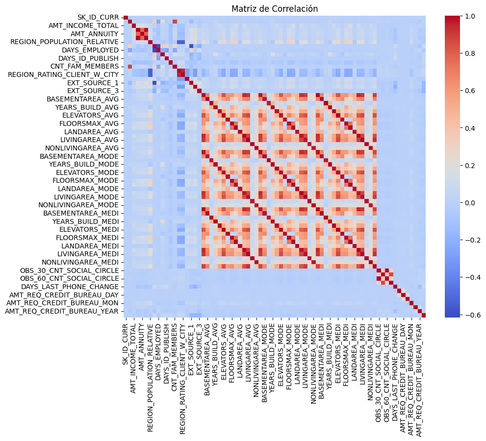

```python
# Pintar la matriz de correlación con seaborn
plt.figure(figsize=(10, 8))  # Tamaño de la figura
sns.heatmap(corr, cmap='coolwarm', fmt='.2f', cbar=True, square=True)

# Añadir título
plt.title('Matriz de Correlación')

# Mostrar el gráfico
plt.show()
```

##### CONCLUSIONES DE LA MATRIZ DE CORRELACIÓN

La matriz de correlación muestra las relaciones lineales entre las variables numéricas del conjunto de datos. A partir de la visualización:

1. **Fuertes correlaciones**: Existen variables altamente correlacionadas, lo que sugiere redundancia entre ellas, como las variables `BASEMENTAREA_AVG`, `BASEMENTAREA_MODE` y `BASEMENTAREA_MEDI`, que están estrechamente relacionadas.
2. **Bajas correlaciones**: La mayoría de las variables muestran correlaciones bajas o cercanas a cero, lo que indica que no tienen una relación lineal fuerte.
3. **Regiones estructuradas**: Se observan bloques de variables con correlaciones consistentes, lo que puede indicar comportamientos similares entre ellas.
4. **Variables independientes**: Algunas variables, como `SK_ID_CURR`, tienen correlaciones bajas con el resto, lo que sugiere que no influyen significativamente en las demás.

#### RELACIONES ENTRE VARIABLES CATEGÓRICAS: CRAMERS V MATRIX

La matriz de Cramér se usa para medir la asociación entre dos variables categóricas. Su coeficiente, Cramér's V, va de 0 (sin relación) a 1 (relación perfecta).

En este caso es de gran utilidad para analizar la dependencia en tablas de contingencia.

Para nuestro dataset de concesión de préstamo permitirá evaluar la relación entre variabes como "género", "tipo de casa", "materiales de la vivienda", "tipo de solicitante" etc con la variable TARGET que toma valor 1 si tuvo algún retraso en alguno de los pagos de la devolución del préstamo y 0 en cualquier otro caso.

Por ello un valor alto de Cramer´s matrix sugiere que esas variables tienen un impacto en la probabilidad de impago.

```python
# Seleccionar las columnas numéricas que tienen solo valores 0 y 1
boolean_columns = df_loans.columns[df_loans.isin([0, 1]).all()]

# Convertir las columnas seleccionadas a tipo booleano
df_loans[boolean_columns] = df_loans[boolean_columns].astype(bool)

# Verifica si las columnas han sido convertidas correctamente
print(df_loans.dtypes)
```

```
SK_ID_CURR                        int64
TARGET                             bool
NAME_CONTRACT_TYPE               object
CODE_GENDER                      object
FLAG_OWN_CAR                     object
FLAG_OWN_REALTY                  object
CNT_CHILDREN                      int64
AMT_INCOME_TOTAL                float64
AMT_CREDIT                      float64
AMT_ANNUITY                     float64
AMT_GOODS_PRICE                 float64
NAME_TYPE_SUITE                  object
NAME_INCOME_TYPE                 object
NAME_EDUCATION_TYPE              object
NAME_FAMILY_STATUS               object
NAME_HOUSING_TYPE                object
REGION_POPULATION_RELATIVE      float64
DAYS_BIRTH                        int64
DAYS_EMPLOYED                     int64
DAYS_REGISTRATION               float64
DAYS_ID_PUBLISH                   int64
OWN_CAR_AGE                     float64
FLAG_MOBIL                         bool
FLAG_EMP_PHONE                     bool
FLAG_WORK_PHONE                    bool
FLAG_CONT_MOBILE                   bool
FLAG_PHONE                         bool
FLAG_EMAIL                         bool
OCCUPATION_TYPE                  object
CNT_FAM_MEMBERS                 float64
REGION_RATING_CLIENT              int64
REGION_RATING_CLIENT_W_CITY       int64
WEEKDAY_APPR_PROCESS_START       object
HOUR_APPR_PROCESS_START           int64
REG_REGION_NOT_LIVE_REGION         bool
REG_REGION_NOT_WORK_REGION         bool
LIVE_REGION_NOT_WORK_REGION        bool
REG_CITY_NOT_LIVE_CITY             bool
REG_CITY_NOT_WORK_CITY             bool
LIVE_CITY_NOT_WORK_CITY            bool
```

[output cut: 68 more lines]

```
FLAG_DOCUMENT_14                   bool
FLAG_DOCUMENT_15                   bool
FLAG_DOCUMENT_16                   bool
FLAG_DOCUMENT_17                   bool
FLAG_DOCUMENT_18                   bool
FLAG_DOCUMENT_19                   bool
FLAG_DOCUMENT_20                   bool
FLAG_DOCUMENT_21                   bool
AMT_REQ_CREDIT_BUREAU_HOUR      float64
AMT_REQ_CREDIT_BUREAU_DAY       float64
AMT_REQ_CREDIT_BUREAU_WEEK      float64
AMT_REQ_CREDIT_BUREAU_MON       float64
AMT_REQ_CREDIT_BUREAU_QRT       float64
AMT_REQ_CREDIT_BUREAU_YEAR      float64
dtype: object
```

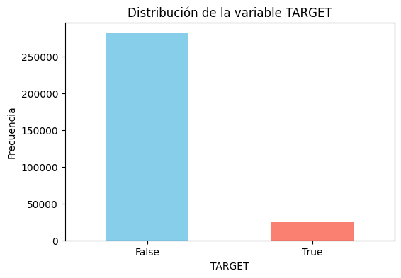

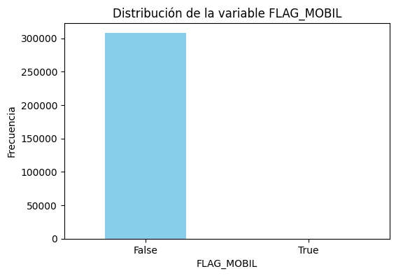

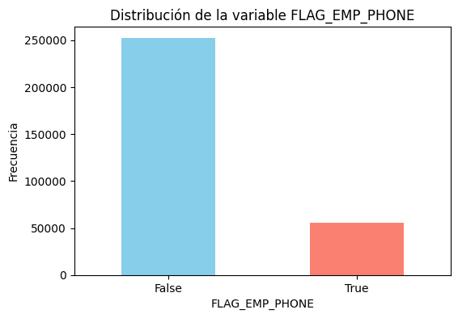

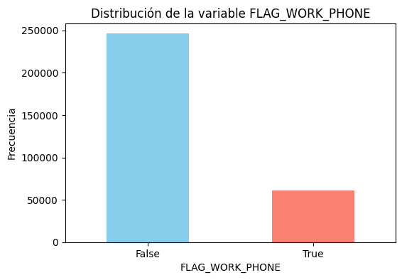

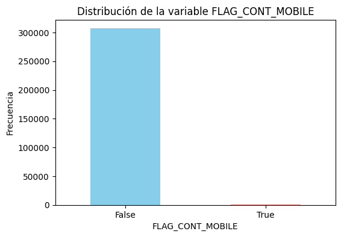

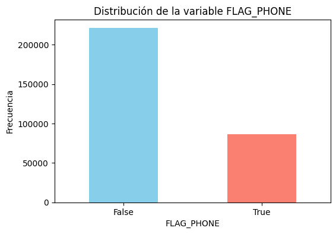

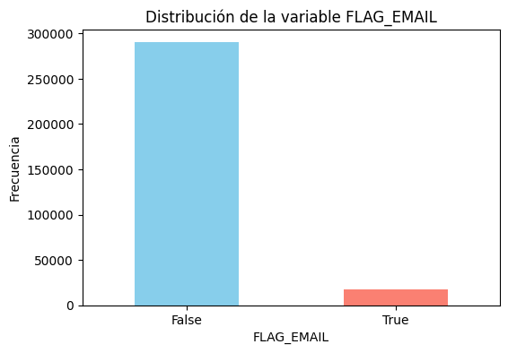

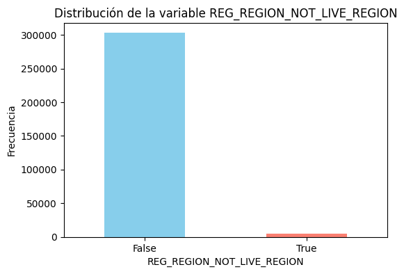

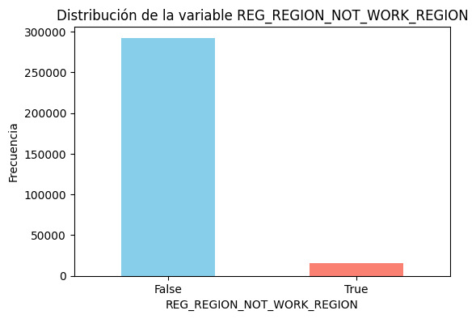

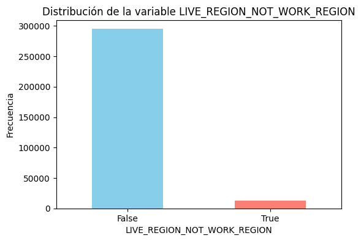

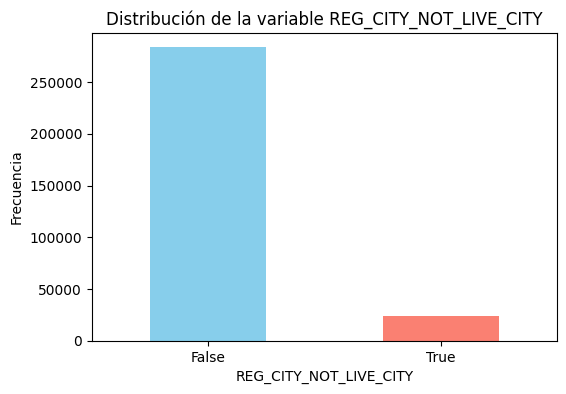

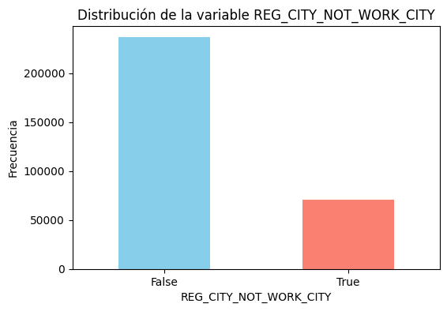

[21 more figures not shown]

```python
# Seleccionamos las columnas booleanas
boolean_columns = df_loans.select_dtypes(include=['bool']).columns

# Crear gráficos de barras para cada variable booleana
for col in boolean_columns:
    plt.figure(figsize=(6, 4))
    df_loans[col].value_counts().plot(kind='bar', color=['skyblue', 'salmon'])
    plt.title(f'Distribución de la variable {col}')
    plt.xlabel(col)
    plt.ylabel('Frecuencia')
    plt.xticks(ticks=[0, 1], labels=['False', 'True'], rotation=0)
    plt.show()
```

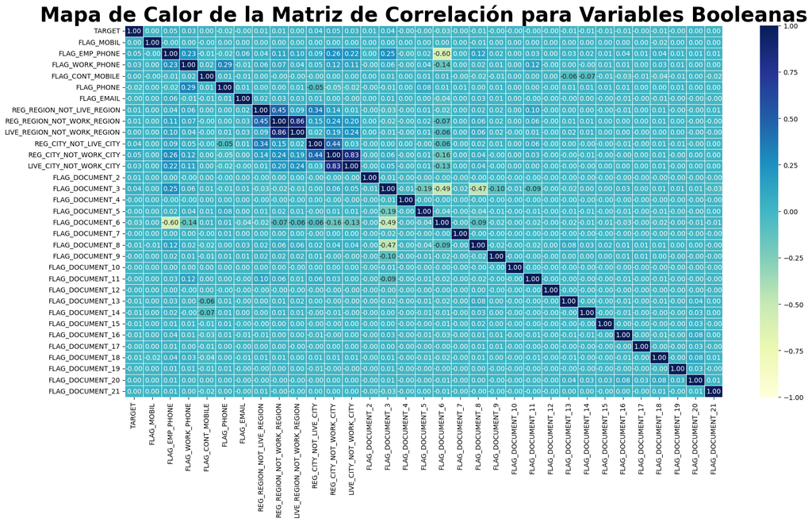

```python
# Calcular la matriz de correlación para las variables booleanas
corr_matrix = df_loans[boolean_columns].corr()

# Crear un mapa de calor para la matriz de correlación
plt.figure(figsize=(20, 10))
sns.heatmap(corr_matrix, annot=True, cmap='YlGnBu', fmt=".2f", linewidths=0.5, vmin=-1, vmax=1)

# Título en negrita y más grande
plt.title('Mapa de Calor de la Matriz de Correlación para Variables Booleanas', fontweight='bold', fontsize=30)
plt.show()
```

##### COMENTARIO DE LA MATRIZ DE BOOLEANOS

La matriz de correlación presentada muestra cómo se relacionan entre sí diferentes variables booleanas del conjunto de datos, incluyendo la variable objetivo TARGET, que indica si un cliente se retrasó en el pago. Cada celda refleja la fuerza de la correlación entre las variables.

En cuanto a TARGET, la mayoría de las correlaciones son bajas, con valores menores a 0.1. Esto indica que las variables booleanas analizadas tienen poca influencia directa sobre el retraso en los pagos.

Variables como FLAG_EMAIL, FLAG_PHONE, y FLAG_DOCUMENT_X presentan correlaciones muy bajas con TARGET, lo que sugiere que estas características no son determinantes en el comportamiento de pago del cliente.

En general, las correlaciones en la matriz son débiles, lo cual es común en análisis de variables booleanas. Sin embargo, es importante evaluar estas relaciones en combinación con otras variables para capturar patrones más complejos y mejorar el modelo predictivo.

```python
# Llamar a la función y guardar los resultados en variables
col_bool, col_cat, col_num = fa.categorizar_columnas(df_loans)
```

```python
# Asegurarte de incluir la variable TARGET
col_cat_str = list(X_df_loans_train[col_cat].select_dtypes('object').columns.values)
col_cat_str
```

```
['NAME_CONTRACT_TYPE',
 'CODE_GENDER',
 'FLAG_OWN_CAR',
 'FLAG_OWN_REALTY',
 'NAME_TYPE_SUITE',
 'NAME_INCOME_TYPE',
 'NAME_EDUCATION_TYPE',
 'NAME_FAMILY_STATUS',
 'NAME_HOUSING_TYPE',
 'OCCUPATION_TYPE',
 'WEEKDAY_APPR_PROCESS_START',
 'ORGANIZATION_TYPE',
 'FONDKAPREMONT_MODE',
 'HOUSETYPE_MODE',
 'WALLSMATERIAL_MODE',
 'EMERGENCYSTATE_MODE']
```

```python
# Agregar manualmente 'TARGET' si no está ya en la lista
if 'TARGET' not in col_cat_str:
    col_cat_str.append('TARGET')

# Crear una matriz vacía para almacenar los valores de Cramér's V
cramers_matrix = pd.DataFrame(index=col_cat_str, columns=col_cat_str)

# Rellenar la matriz con los valores de Cramér's V
for col1 in col_cat_str:
    for col2 in col_cat_str:
        # Crear la tabla de contingencia
        confusion_matrix = pd.crosstab(df_loans_train[col1], df_loans_train[col2])
        # Calcular Cramér's V
        cramers_matrix.loc[col1, col2] = fa.cramers_v(confusion_matrix.values)
```

```python
# Convertir los valores a float para que se puedan leer adecuadamente
cramers_matrix = cramers_matrix.astype(float)

# Imprimir la matriz de Cramér's V
print(cramers_matrix)
```

```
                            NAME_CONTRACT_TYPE  CODE_GENDER  FLAG_OWN_CAR  \
NAME_CONTRACT_TYPE                    0.999976     0.014834      0.003962
CODE_GENDER                           0.014834     1.000000      0.345505
FLAG_OWN_CAR                          0.003962     0.345505      0.999991
FLAG_OWN_REALTY                       0.067212     0.045307      0.003079
NAME_TYPE_SUITE                       0.012918     0.044500      0.042270
NAME_INCOME_TYPE                      0.061611     0.119738      0.156138
NAME_EDUCATION_TYPE                   0.068257     0.017361      0.095628
NAME_FAMILY_STATUS                    0.044942     0.118789      0.167965
NAME_HOUSING_TYPE                     0.026925     0.046605      0.040032
OCCUPATION_TYPE                       0.057137     0.404954      0.262703
WEEKDAY_APPR_PROCESS_START            0.014584     0.004973      0.003499
ORGANIZATION_TYPE                     0.066098     0.238837      0.200754
FONDKAPREMONT_MODE                    0.006604     0.007519      0.012242
HOUSETYPE_MODE                        0.000442     0.003882      0.009489
WALLSMATERIAL_MODE                    0.014187     0.010662      0.023735
EMERGENCYSTATE_MODE                   0.002155     0.000000      0.004696
TARGET                                0.033178     0.055597      0.021089

                            FLAG_OWN_REALTY  NAME_TYPE_SUITE  \
NAME_CONTRACT_TYPE                 0.067212         0.012918
CODE_GENDER                        0.045307         0.044500
FLAG_OWN_CAR                       0.003079         0.042270
FLAG_OWN_REALTY                    0.999990         0.058231
NAME_TYPE_SUITE                    0.058231         1.000000
NAME_INCOME_TYPE                   0.070920         0.021561
NAME_EDUCATION_TYPE                0.030863         0.023188
NAME_FAMILY_STATUS                 0.051416         0.067726
NAME_HOUSING_TYPE                  0.224187         0.019305
OCCUPATION_TYPE                    0.028529         0.021776
WEEKDAY_APPR_PROCESS_START         0.025994         0.016015
ORGANIZATION_TYPE                  0.077293         0.025983
FONDKAPREMONT_MODE                 0.014333         0.004958
HOUSETYPE_MODE                     0.016184         0.003117
WALLSMATERIAL_MODE                 0.025182         0.009398
EMERGENCYSTATE_MODE                0.014527         0.000000
TARGET                             0.006795         0.010325

                            NAME_INCOME_TYPE  NAME_EDUCATION_TYPE  \
NAME_CONTRACT_TYPE                  0.061611             0.068257
```

[output cut: 96 more lines]

```
FLAG_OWN_CAR                           0.004696  0.021089
FLAG_OWN_REALTY                        0.014527  0.006795
NAME_TYPE_SUITE                        0.000000  0.010325
NAME_INCOME_TYPE                       0.020772  0.063679
NAME_EDUCATION_TYPE                    0.032902  0.057334
NAME_FAMILY_STATUS                     0.004773  0.039791
NAME_HOUSING_TYPE                      0.030303  0.037736
OCCUPATION_TYPE                        0.023498  0.081117
WEEKDAY_APPR_PROCESS_START             0.006354  0.003131
ORGANIZATION_TYPE                      0.016034  0.072013
FONDKAPREMONT_MODE                     0.137053  0.010919
HOUSETYPE_MODE                         0.036954  0.012948
WALLSMATERIAL_MODE                     0.320206  0.028664
EMERGENCYSTATE_MODE                    0.999731  0.011496
TARGET                                 0.011496  0.999973
```

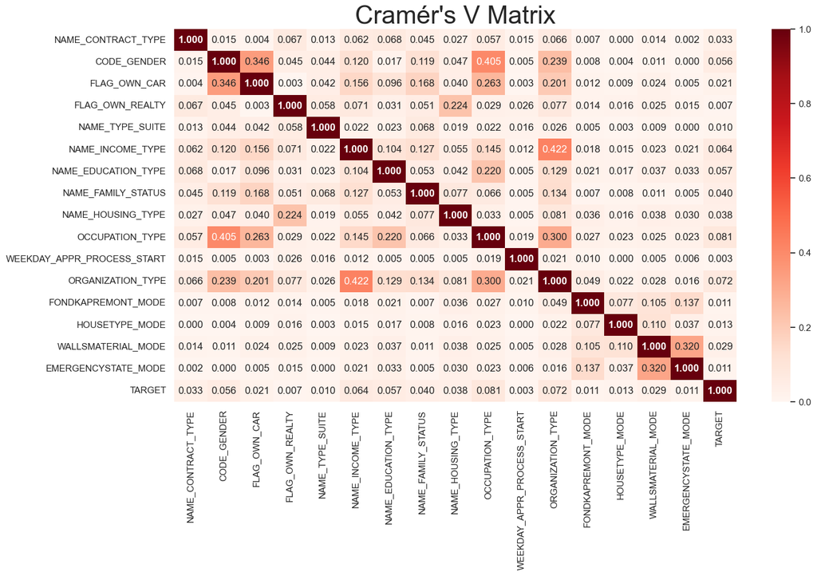

```python
# Ajustar el esquema de colores y mostrar la matriz
plt.figure(figsize=(15, 8))
sns.set(style='white')  # Estilo más limpio
# Crear el mapa de calor con colores rosas
ax = sns.heatmap(cramers_matrix, annot=True, fmt='.3f', cmap='Reds', cbar=True)

# Iterar sobre las anotaciones para poner en negrita los valores altos
for text in ax.texts:
    if float(text.get_text()) > 0.5:  # Umbral de correlación alta
        text.set_fontweight('bold')

# Añadir título y personalizarlo
plt.title('Cramér\'s V Matrix', fontdict={'size': 17},fontsize=30)
plt.show()
```

#### TRATAMIENTO DE LOS VALORES NULOS

Para el tratamiento de valores nulos se ha decidido reemplazar los valores faltantes por el valor "Desconocido" con el fin de no perder valor en los datos.

```python
fa.reemplazar_nulos_por_desconocido(df_loans_train)
```

## WOE y Valor de la Información (Information Value)

#### WOE (Weight of Evidence)

**1- DEFINCIÓN**

WOE (The Weight of Evidence) indica el poder predictivo de una variable independiente en relación con la variable dependiente. Originado en el ámbito de la evaluación crediticia, generalmente se describe como una medida de la capacidad de separación entre buenos y malos clientes. Los "Malos Clientes" se refieren a aquellos que incumplieron con el pago de un préstamo (en este caso sería aquellos clienten que tienen dificultades de pago), mientras que los "Buenos Clientes" son los que lo reembolsaron, es decir, aquellos que no tuvieron dificultades durante el reembolso.

Es decir, el WOE mide qué tan bien cada grupo de atributos puede predecir el valor deseado de la variable dependiente.

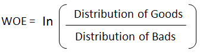

- Distribution of Goods - % de buenos clientes (aquellos sin dificultad de pago) en un grupo particular.
- Distribution of Bads - % de malos clientes (aquellos con dificultad de pago) en un grupo particular.
- ln - Logaritmo natural

**2- PASOS**

**Paso 1. Verifica el tipo de variable:**

```
Si es continua
```

Divide los datos en 10 grupos (o menos, dependiendo de la distribución). Idealmente, cada grupo debe contener al menos el 5% de los casos.

```
Si es categórica
```

Omite este paso.

**Paso 2. Cuenta los valores buenos y malos en cada grupo:**

"Buenos" se refieren a eventos positivos (por ejemplo, clientes que pagaron).  
"Malos" se refieren a eventos negativos (por ejemplo, clientes que incumplieron).

**Paso 3. Calcula el % de buenos y malos** Mediante la fórmula

**Paso 4. Calcula el WOE para cada grupo**

**Paso 5. Agrupa categorías con WOE similares:** Si una variable tiene múltiples grupos, puedes combinarlos si tienen valores de WOE similares, ya que su comportamiento al predecir la variable objetivo será comparable. Esto simplifica el modelo y mejora la interpretabilidad.

**3- Interpretación de posibles Resultados:**

- Un WOE positivo indica que la distribución de los buenos (clientes que pagaron el préstamo) es mayor que la de los malos (clientes que incumplieron). Esto sugiere que esa categoría o grupo tiene una proporción relativamente alta de eventos positivos.
- Un WOE negativo indica que la distribución de los buenos es menor que la de los malos. Esto implica que esa categoría o grupo tiene una proporción relativamente alta de eventos negativos.

La interpretación del WOE es esencial para evaluar la relación entre una variable independiente y el comportamiento de la variable dependiente (la dificultad de pago).

#### Valor de la Información (Information Value)

El Valor de la Información (IV) y el Peso de la Evidencia (WOE) tienen una conexión directa y significativa.

El IV es un método de análisis exploratorio que ayuda a identificar qué variable en un conjunto de datos posee capacidad predictiva o impacto sobre el valor de una variable dependiente binaria específica (0 o 1). En otras palabras, es un indicador numérico que mide la capacidad general de una variable independiente 𝑋 para predecir el comportamiento de la variable objetivo.

#### **Fórmula del Valor de la Información**

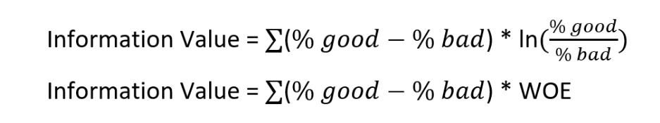

El Valor de la Información (IV) resulta útil para reducir el número de variables empleadas al crear un modelo de Regresión Logística, particularmente cuando existen muchas variables potenciales. El IV examina cada variable independiente de manera individual, sin tener en cuenta las otras variables predictoras. Dependiendo de los valores de IV de cada variable, se puede evaluar su poder predictivo utilizando la siguiente lógica:

- IV < 0.02: La variable no tiene poder predictivo (no es útil para el modelo).
- 0.02 ≤ IV < 0.1: La variable tiene un poder predictivo débil.
- 0.1 ≤ IV < 0.3: La variable tiene un poder predictivo moderado.
- IV ≥ 0.3: La variable tiene un poder predictivo fuerte (puede ser muy influyente en el modelo).

Este enfoque permite priorizar las variables más relevantes y descartar aquellas que no aportan valor significativo al modelo, optimizando tanto su precisión como su eficiencia.

#### Variables catgoricas (WOE y IV)

```python
# Calcular y mostrar el WOE e IV para cada variable categórica
categoric_val = df_loans.select_dtypes(['category', 'object']).columns

for var in categoric_val:
    print(f"Resultados para la variable categórica: {var}")

    try:
        # Calcular WOE e IV
        woe_iv = fa.calculate_woe_iv_cat(df_loans, var, 'TARGET')

        # Imprimir los resultados
        print(woe_iv[['WOE', 'IV']])  # Muestra solo las columnas WOE e IV por categoría
        iv_total = woe_iv['IV_Total'].iloc[0]  # IV Total
        print(f"IV Total para {var}: {iv_total:.4f}")

        # Clasificar la relevancia de la variable
        if iv_total < 0.02:
            print(f"La variable {var} no es relevante para el modelo.")
        elif 0.02 <= iv_total < 0.1:
            print(f"La variable {var} tiene un impacto moderado en el modelo.")
        else:
            print(f"La variable {var} tiene un impacto fuerte en el modelo.")
    except Exception as e:
        print(f"Error procesando la variable {var}: {e}")

    print("\n" + "-" * 50 + "\n")
```

[output not shown]

[output cut: 24 more lines]

```

Resultados para la variable categórica: HOUSETYPE_MODE
Error procesando la variable HOUSETYPE_MODE: 1

--------------------------------------------------

Resultados para la variable categórica: WALLSMATERIAL_MODE
Error procesando la variable WALLSMATERIAL_MODE: 1

--------------------------------------------------

Resultados para la variable categórica: EMERGENCYSTATE_MODE
Error procesando la variable EMERGENCYSTATE_MODE: 1

--------------------------------------------------
```

#### Resultados del WOE y DE IV de variables categóricas

**NAME_FAMILY_STATUS**

**VARIABLE OCCUPATION_TYPE**

#### GUARDADO DE LAS TABLAS

```python
df_loans_train.to_csv('../data/Processing_data/df_loans_train.csv')
df_loans_test.to_csv('../data/Processing_data/df_loans_test.csv')
```